# POP77022: Programming Exercise 2

```r
#adjustemnt testing issue
dfm_y <- dfm_trim(dfm_y, min_docfreq = 1500) # trim DFM
dfm_y <- dfm_tfidf(dfm_y) # weight DFM

tmpdata <- convert(dfm_y, to = "data.frame", docvars = NULL)
tmpdata <- tmpdata[, -1] # drop document id variable (first variable)
#sentiment_labels <- dfm_y@docvars$sentiment # get section labels - note, the @ operator is specific to S4 class object
sentiment_labels <- dfm_y@docvars$docname_ # get section labels - note, the @ operator is specific to S4 class object
tmpdata <- as.data.frame(cbind(sentiment_labels, tmpdata)) # labelled data frame
##pointless words get,time,one,just
```

3. Now that you have your document-feature matrix, use the `caret` library to create a training set and testing set following an 80/20 split.

```r
set.seed(2023) # set seed for replicability
tmpdata <- tmpdata[sample(nrow(tmpdata)), ] # randomly order labelled dataset
#split <- round(nrow(tmpdata) * 0.05) # determine cutoff point of 5% of documents
split <- round(nrow(tmpdata) * 0.01) # determine cutoff point of 5% of documents
vdata <- tmpdata[1:split, ] # validation set
ldata <- tmpdata[(split + 1):nrow(tmpdata), ] # labelled dataset minus validation set

#             b) Create an 80/20 test/train split
train_row_nums <- createDataPartition(ldata$sentiment,
                                      p=0.8,
                                      list=FALSE) # set human_labels as the Y variable in caret
```

[output not shown]

[output cut: 50 more lines]

[output not shown]

```r
Train <- ldata[train_row_nums, ] # training set
Test <- ldata[-train_row_nums, ] # testing set
##The og stack overflow lol
'ulimit -s unlimited'
```

```
## [1] "ulimit -s unlimited"
```

```r
train_control <- readRDS("~/Desktop/QTA_Spring23/Homework2/train_control")
```

```r
train_control <- trainControl(
  method = "repeatedcv",
  number = 5,
  repeats = 3,
  classProbs= TRUE,
  summaryFunction = multiClassSummary,
  selectionFunction = "best", # select the model with the best performance metric
  verboseIter = TRUE
)
```

4. Using these datasets, train a naive Bayes classifier with the `caret` library to predict review sentiment. Explain each step you take in the learning pipeline. Be sure to:
   - Evaluate the performance of the model in terms of classification accuracy of predictions in the testing set. Include a discussion of precision, recall and F1.
   - Explain in detail what steps were taken to help avoid overfitting.
   - Describe your parameter tuning.
   - Discuss the most predictive features of the dataset. (*Hint: use `kwic` to provide a qualitative context)

```r
modelLookup(model = "naive_bayes")
```

```
##         model parameter                label forReg forClass probModel
## 1 naive_bayes   laplace   Laplace Correction  FALSE     TRUE      TRUE
## 2 naive_bayes usekernel    Distribution Type  FALSE     TRUE      TRUE
## 3 naive_bayes    adjust Bandwidth Adjustment  FALSE     TRUE      TRUE
```

```r
#             b) Create a matrix of combinations of parameters to supply to tuneGrid arg of train()
tuneGrid <- expand.grid(laplace = c(0,0.5,1.0),
                        usekernel = c(TRUE, FALSE),
                        adjust=c(0.75, 1, 1.25, 1.5))

tuneGrid
```

```
##    laplace usekernel adjust
## 1      0.0      TRUE   0.75
## 2      0.5      TRUE   0.75
## 3      1.0      TRUE   0.75
## 4      0.0     FALSE   0.75
## 5      0.5     FALSE   0.75
## 6      1.0     FALSE   0.75
## 7      0.0      TRUE   1.00
## 8      0.5      TRUE   1.00
## 9      1.0      TRUE   1.00
## 10     0.0     FALSE   1.00
## 11     0.5     FALSE   1.00
## 12     1.0     FALSE   1.00
## 13     0.0      TRUE   1.25
## 14     0.5      TRUE   1.25
## 15     1.0      TRUE   1.25
## 16     0.0     FALSE   1.25
## 17     0.5     FALSE   1.25
## 18     1.0     FALSE   1.25
## 19     0.0      TRUE   1.50
## 20     0.5      TRUE   1.50
## 21     1.0      TRUE   1.50
## 22     0.0     FALSE   1.50
## 23     0.5     FALSE   1.50
## 24     1.0     FALSE   1.50
```

```r
#             c) Set up parallel processing
cl <- makePSOCKcluster(7) # create number of copies of R to run in parallel and communicate over sockets
# Note that the number of clusters depends on how many cores your machine has.
registerDoParallel(cl) # register parallel backed with foreach package
```

```r
nb_train <- train(sentiment_labels ~ .,
                  data = Train,
                  method = "naive_bayes",
                  metric = "F1",
                  trControl = train_control,
                  tuneGrid = tuneGrid,
                  allowParallel= TRUE
)
```

5. Provide a similar analysis using a Support Vector Machine. However, irrespective of your settings for Question 4, for this excercise use a 5-fold cross-validation when training the model. Be sure to explain all steps involved as well as an evaluation of model performance. Which model is better, NB or SVM? Explain in detail.

## Topic Modeling Breitbart News (50 points)

In this section, we will analyze the thematic structure of a corpus of news articles from Breitbart News, a right-wing American news outlet. Employ a Structural Topic Model from the `stm` library to investigate the themes found within this corpus.

First, bring in a sample of Breitbart articles from 2016 (n=5000):

```r
setwd(getwd())
data <- read.csv("~/Desktop/QTA_Spring23/Homework2/breitbart_2016_sample.csv",
                 stringsAsFactors=FALSE,
                 encoding = "utf-8")
if(!require(devtools)) install.packages("devtools")
library(devtools)
install_github("mroberts/stmBrowser",dependencies=TRUE)
```

```
## Skipping install of 'stmBrowser' from a github remote, the SHA1 (ecbc4e14) has not changed since last install.
##   Use `force = TRUE` to force installation
```

```r
lapply(c("tidyverse",
         "quanteda",
         "quanteda.textstats",
         "lubridate",
         "stm",
         "wordcloud",
         "stmBrowser",
         "LDAvis"),
       pkgTest)
```

```
## stm v1.3.6 successfully loaded. See ?stm for help.
##  Papers, resources, and other materials at structuraltopicmodel.com
```

[output not shown]

1. Process the text and generate a document-feature matrix. Be sure to remove unhelpful characters and tokens from the DFM and to also retain the original text for model validation. Remove tokens that occur in less than 20 documents. Justify your feature selection decisions.

```r
dfm <- readRDS("~/Desktop/QTA_Spring23/Homework2/dfm")
toks <- readRDS("~/Desktop/QTA_Spring23/Homework2/toks")
```

```r
corp <- corpus(data,
               docid_field = "title",
               text_field = "content")

prepped_toks <- prep_toks(corp) # basic token cleaning
collocations <- get_coll(prepped_toks) # get collocations
toks <- tokens_compound(prepped_toks, pattern = collocations[collocations$z > 10,]) # replace collocations
toks <- tokens_remove(tokens(toks), "") # let's also remove the whitespace placeholders

toks <- tokens(toks,
               remove_numbers = TRUE,
               remove_punct = TRUE,
               remove_symbols = TRUE,
               remove_separators = TRUE,
               remove_url = TRUE,
) # remove other uninformative text
toks <- tokens_remove(toks, c(),
                      valuetype = "fixed")
# Create dfm and weight using tf/idf
dfm <- dfm(toks) # create DFM

dfm <- dfm_trim(dfm, min_docfreq = 20) # trim DFM
```

2. Convert the DFM into STM format and fit an STM model with `k=35` topics.

```r
stmdfm <- readRDS("~/Desktop/QTA_Spring23/Homework2/stmdfm")
modelFit <- readRDS("~/Desktop/QTA_Spring23/Homework2/modelFit")
K <- 35
```

```r
stmdfm <- convert(dfm, to = "stm")

# Set k
K <- 35
# Run STM algorithm
modelFit <- stm(documents = stmdfm$documents,
                vocab = stmdfm$vocab,
                K = K,
                #prevalence = ~ title + s(as.numeric(date)),
                #prevalence = ~ source + s(as.numeric(date_month)),
                data = stmdfm$meta,
                max.em.its = 500,
                init.type = "Spectral",
                seed = 2023,
                verbose = TRUE)
```

3. Interpret the topics generated by the STM model. Discuss the prevalence and top terms of each topic. Provide a list of the labels you have associated with each estimated topic. For each topic, justify your labelling decision. (Hint: You will want to cite excerpts from typical tweets of a given topic. Also, use the date variable to inform estimates of topic prevalence.).

```r
# Inspect most probable terms in each topic
labelTopics(modelFit)
```

```
## Topic 1 Top Words:
##       Highest Prob: people, going, get, says, want, asked, know
##       FREX: get, going, want, people, says, asked, know
##       Lift: employ, trump_supporter, everybody, secret_service, get, replied, make_sure
##       Score: people, employ, get, going, says, think, know
## Topic 2 Top Words:
##       Highest Prob: city, army, iraq, killed, people, soldiers, civilians
##       FREX: mosul, army, civilians, iraqi, soldiers, troops, village
##       Lift: iraqi_forces, battles, syrian_observatory, mosul, villages, village, militia
##       Score: mosul, battles, aleppo, civilians, iraqi_forces, isis, troops
## Topic 3 Top Words:
##       Highest Prob: game, team, win, season, first, play, one
##       FREX: game, season, smith, player, team, coach, career
##       Lift: demonstration, playoff, scored, quarterback, championship, season, game
##       Score: game, demonstration, nfl, games, players, nba, season
## Topic 4 Top Words:
##       Highest Prob: internet, system, technology, use, new, can, information
##       FREX: internet, google, users, technology, cyber, app, gaming
##       Lift: switch, snarky_opinions, hackers, latest_news, cyber, gaming, google
##       Score: google, users, switch, internet, technology, hackers, snarky_opinions
## Topic 5 Top Words:
##       Highest Prob: company, business, employees, million, companies, billion, according
##       FREX: company, employees, sales, sold, products, plane, passengers
##       Lift: library, company, brands, inc, corp, yahoo, passengers
##       Score: company, library, employees, apple, companies, products, passengers
## Topic 6 Top Words:
##       Highest Prob: de, el, breitbart_texas, la, tamaulipas, y, en
##       FREX: el, tamaulipas, y, que, por, coahuila, las
##       Lift: se, una, y, amordazan, arriesgar_sus_vidas_para_exhibir, award_winning_journalist, breitbart_texas_traveled
##       Score: tamaulipas, por, una, de, coahuila, que, el
## Topic 7 Top Words:
##       Highest Prob: just, like, think, one, know, even, really
##       FREX: really, things, kind, think, yes, understand, always
##       Lift: universe, really, yeah, kid, little_bit, stuff, yes
##       Score: think, universe, really, know, yeah, maybe, guy
## Topic 8 Top Words:
##       Highest Prob: muslim, muslims, islam, islamic, world, religious, religion
##       FREX: islam, muslim, muslims, mosque, sharia, islamic, allah
##       Lift: islamic_law, machines, islam, muslim_community, imam, sharia, muslim
##       Score: muslims, islam, muslim, islamic, machines, christians, mosque
```

[output cut: 120 more lines]

```
## Topic 33 Top Words:
##       Highest Prob: twitter, facebook, media, story, breitbart, news, wrote
##       FREX: breitbart, facebook, tweet, tweets, page, facebook_page, racist
##       Lift: allum_bokhari, milo, milo_alert, milo_yiannopoulos, yiannopoulos, censorship, facebook_page
##       Score: milo_yiannopoulos, facebook, milo, yiannopoulos, racist, users, breitbart_tech
## Topic 34 Top Words:
##       Highest Prob: church, abortion, planned_parenthood, christian, life, god, williams
##       FREX: abortion, church, pope, catholic, follow_thomas_d, http, planned_parenthood
##       Lift: fjs, js, cdata, give_us, https, pope, http
##       Score: abortion, planned_parenthood, church, fjs, js, http, give_us
## Topic 35 Top Words:
##       Highest Prob: city, police, protesters, black, protest, group, event
##       FREX: protesters, black_lives_matter, protest, protests, black, cops, chicago
##       Lift: city_hall, rent, protesters, chanting, demonstrators, baton_rouge, black_lives_matter
##       Score: protesters, rent, black_lives_matter, police, chicago, protest, protests
```

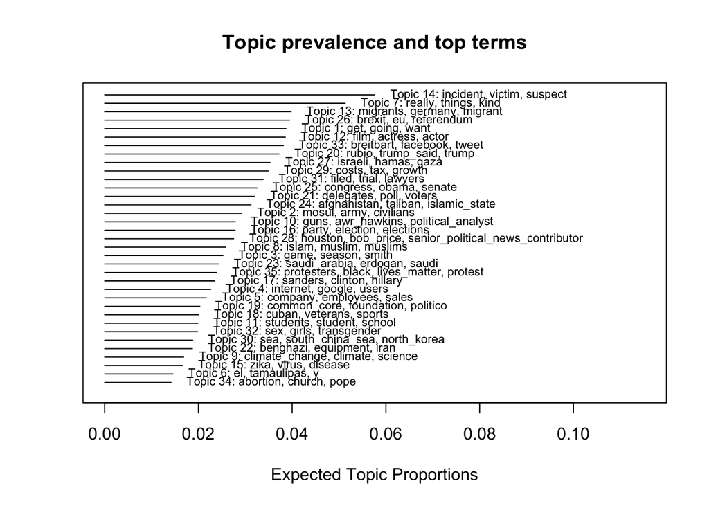

```r
#Highets prob
#FREX freqiency and exclusivity
#lift >1 means word appears more than expected

# Further interpretation: plotting frequent terms
plot.STM(modelFit,
         type = "summary",
         labeltype = "frex", # plot according to FREX metric
         text.cex = 0.7,
         main = "Topic prevalence and top terms")
```

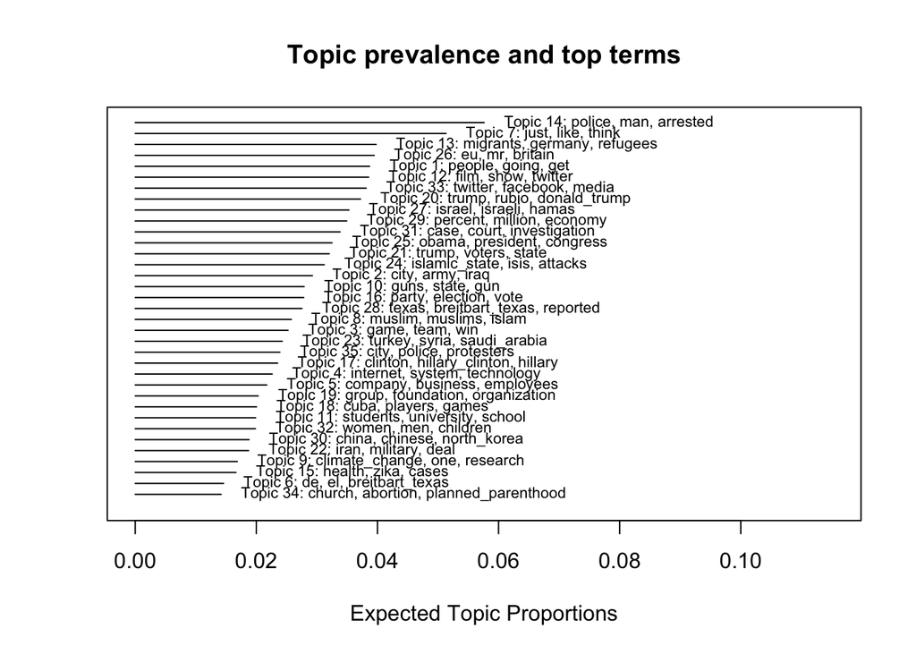

```r
plot.STM(modelFit,
         type = "summary",
         labeltype = "prob", # plot according to probability
         text.cex = 0.7,
         main = "Topic prevalence and top terms")
```

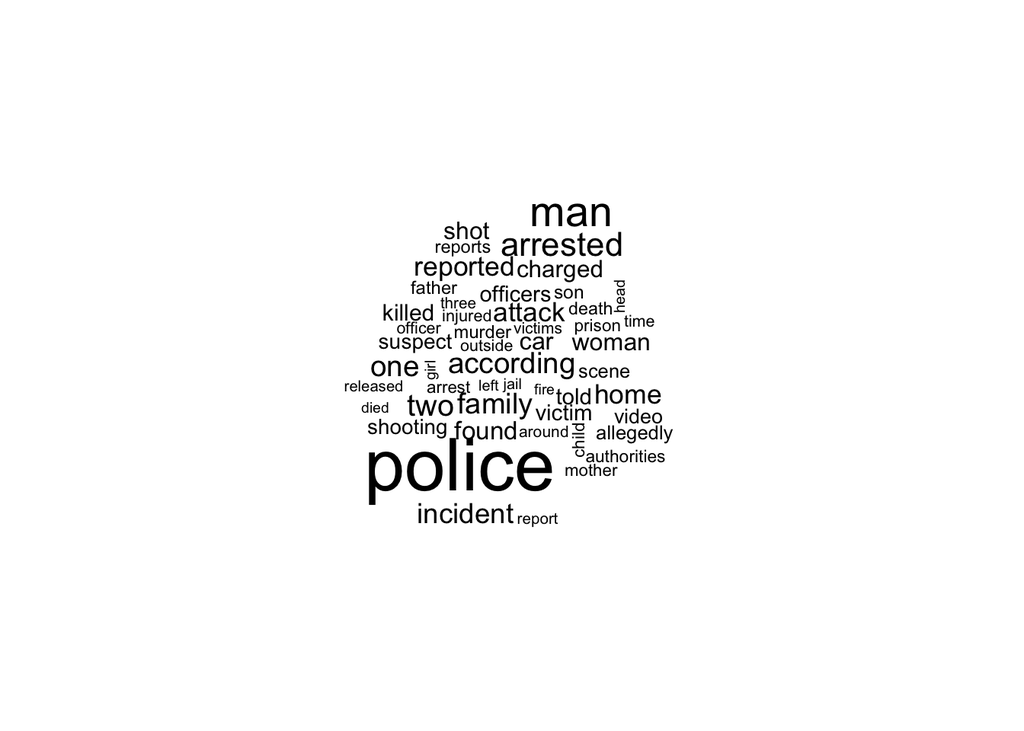

```r
# Use wordcloud to visualise top terms per topic
#14,7,13,26,1,12,33,20,27,29,21,25

cloud(modelFit,
      topic = 14,
      scale = c(3, 0.3),
      max.words = 50)
```

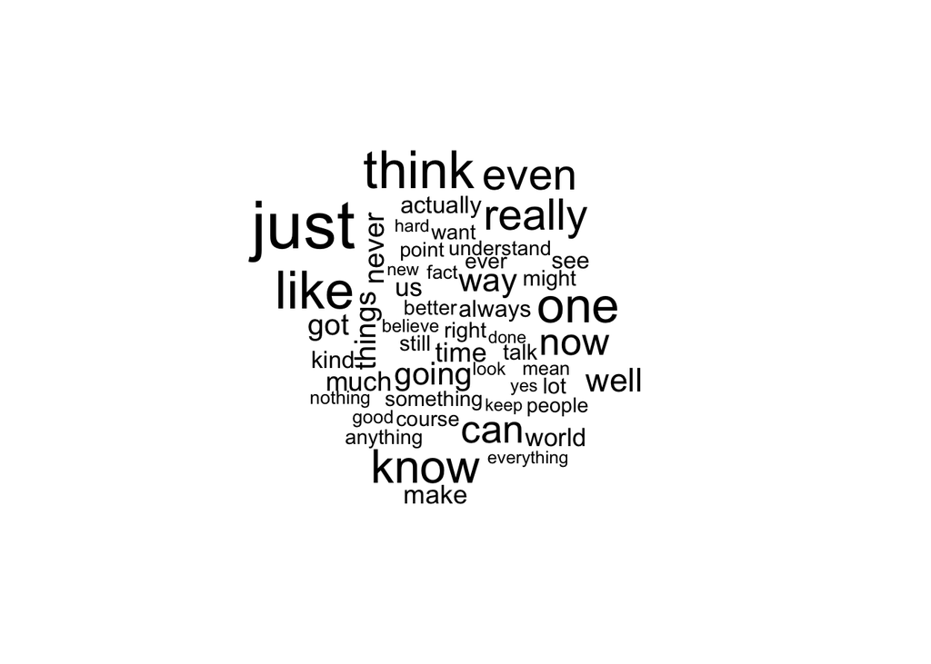

```r
cloud(modelFit,
      topic = 7,
      scale = c(3, 0.3),
      max.words = 50)
```

[figure not shown]

```r
cloud(modelFit,
      topic = 13,
      scale = c(3, 0.3),
      max.words = 50)
```

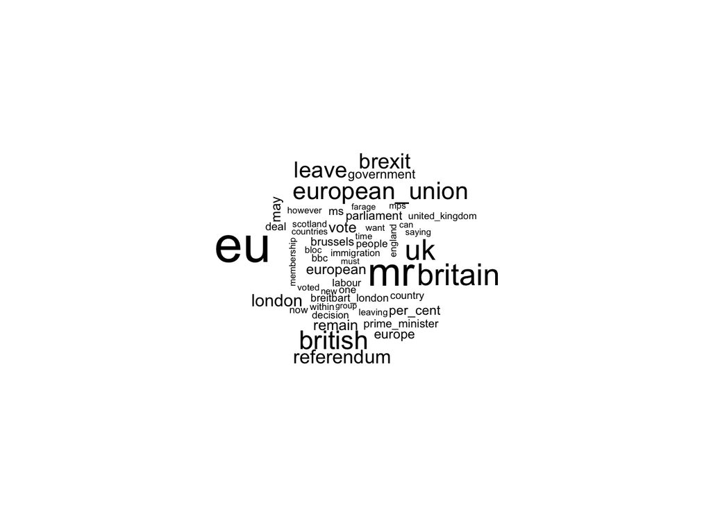

```r
cloud(modelFit,
      topic = 26,
      scale = c(3, 0.3),
      max.words = 50)
```

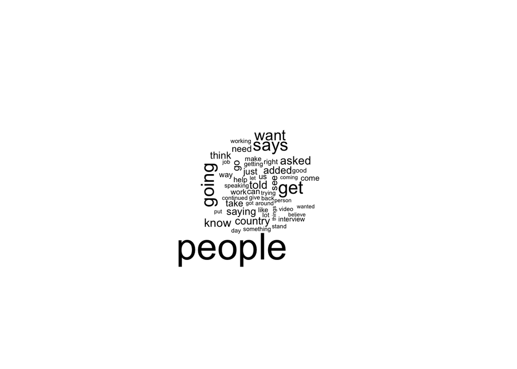

```r
cloud(modelFit,
      topic = 1,
      scale = c(3, 0.3),
      max.words = 50)
```

[figure not shown]

```r
cloud(modelFit,
      topic = 12,
      scale = c(3, 0.3),
      max.words = 50)
```

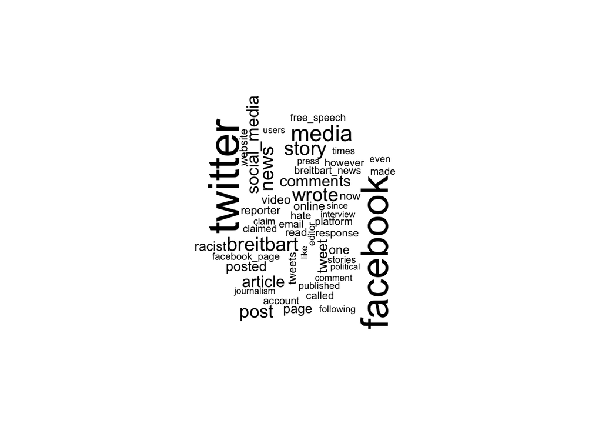

```r
cloud(modelFit,
      topic = 33,
      scale = c(3, 0.3),
      max.words = 50)
```

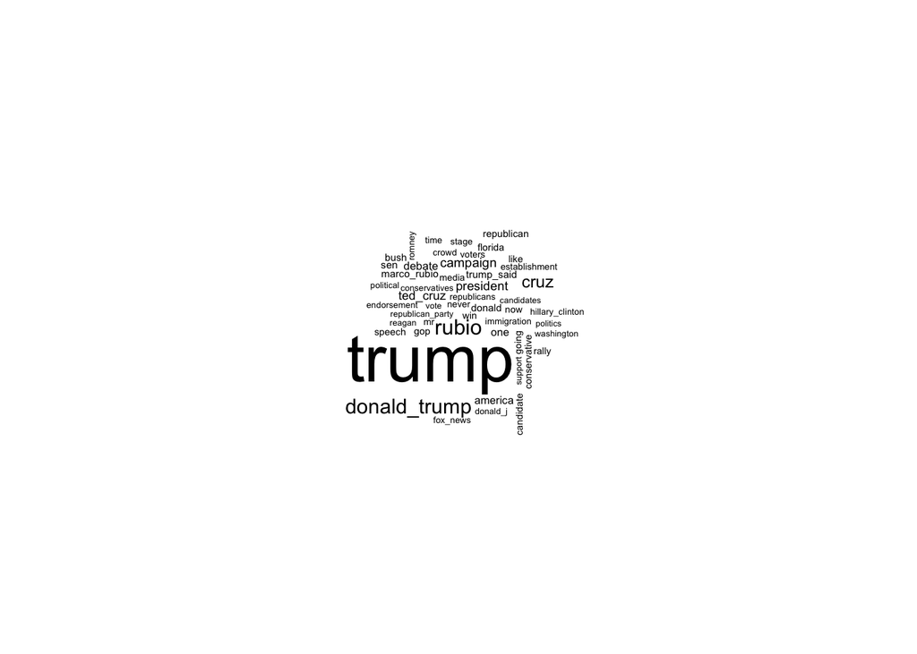

```r
cloud(modelFit,
      topic = 20,
      scale = c(3, 0.3),
      max.words = 50)
```

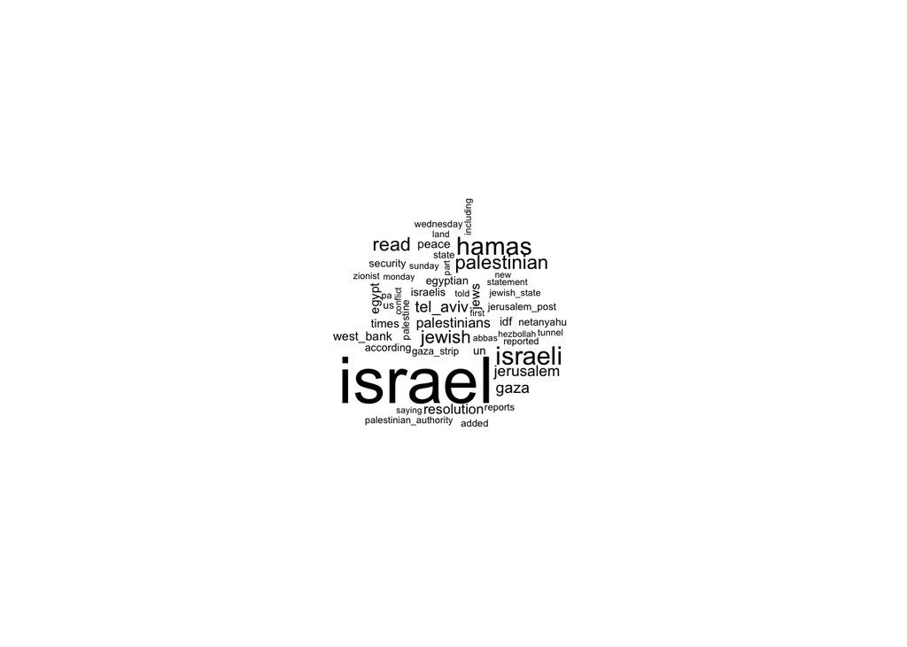

```r
cloud(modelFit,
      topic = 27,
      scale = c(3, 0.3),
      max.words = 50)
```

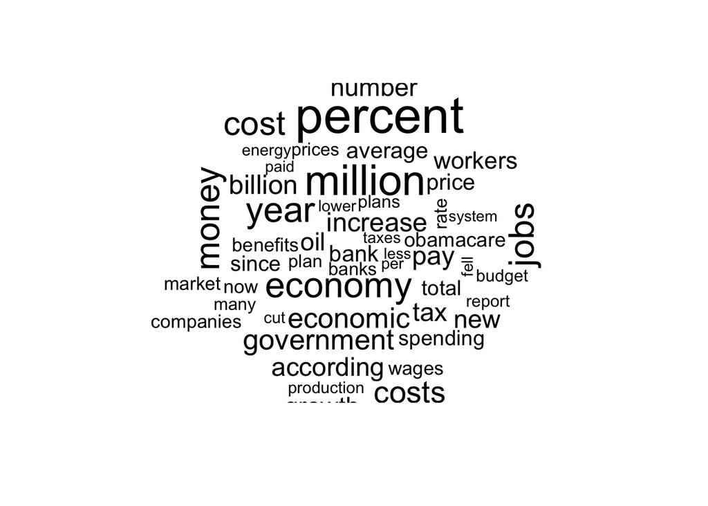

```r
cloud(modelFit,
      topic = 29,
      scale = c(3, 0.3),
      max.words = 50)
```

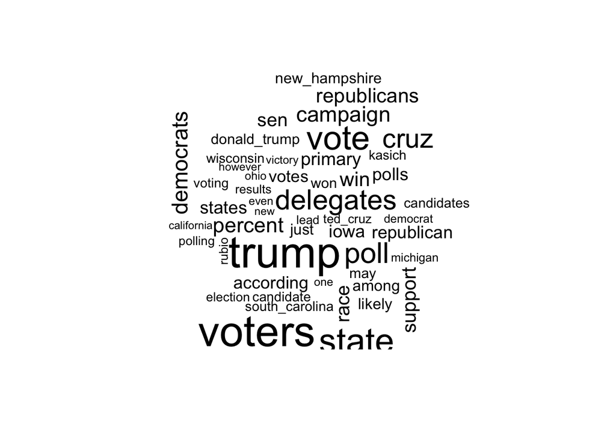

```r
cloud(modelFit,
      topic = 21,
      scale = c(3, 0.3),
      max.words = 50)
```

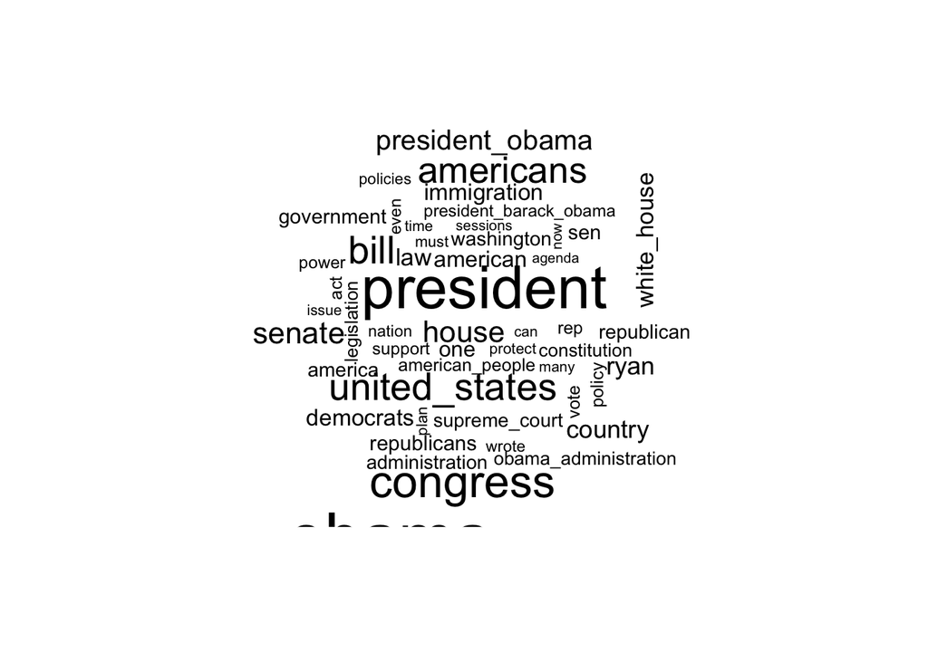

```r
cloud(modelFit,
      topic = 25,
      scale = c(3, 0.3),
      max.words = 50)
```

```r
###Q3 discuss All
summary(modelFit)
```

```
## A topic model with 35 topics, 4999 documents and a 7364 word dictionary.
```

```
## Topic 1 Top Words:
##       Highest Prob: people, going, get, says, want, asked, know
##       FREX: get, going, want, people, says, asked, know
##       Lift: employ, trump_supporter, everybody, secret_service, get, replied, make_sure
##       Score: people, employ, get, going, says, think, know
## Topic 2 Top Words:
##       Highest Prob: city, army, iraq, killed, people, soldiers, civilians
##       FREX: mosul, army, civilians, iraqi, soldiers, troops, village
##       Lift: iraqi_forces, battles, syrian_observatory, mosul, villages, village, militia
##       Score: mosul, battles, aleppo, civilians, iraqi_forces, isis, troops
## Topic 3 Top Words:
##       Highest Prob: game, team, win, season, first, play, one
##       FREX: game, season, smith, player, team, coach, career
##       Lift: demonstration, playoff, scored, quarterback, championship, season, game
##       Score: game, demonstration, nfl, games, players, nba, season
## Topic 4 Top Words:
##       Highest Prob: internet, system, technology, use, new, can, information
##       FREX: internet, google, users, technology, cyber, app, gaming
##       Lift: switch, snarky_opinions, hackers, latest_news, cyber, gaming, google
##       Score: google, users, switch, internet, technology, hackers, snarky_opinions
## Topic 5 Top Words:
##       Highest Prob: company, business, employees, million, companies, billion, according
##       FREX: company, employees, sales, sold, products, plane, passengers
##       Lift: library, company, brands, inc, corp, yahoo, passengers
##       Score: company, library, employees, apple, companies, products, passengers
## Topic 6 Top Words:
##       Highest Prob: de, el, breitbart_texas, la, tamaulipas, y, en
##       FREX: el, tamaulipas, y, que, por, coahuila, las
##       Lift: se, una, y, amordazan, arriesgar_sus_vidas_para_exhibir, award_winning_journalist, breitbart_texas_traveled
##       Score: tamaulipas, por, una, de, coahuila, que, el
## Topic 7 Top Words:
##       Highest Prob: just, like, think, one, know, even, really
##       FREX: really, things, kind, think, yes, understand, always
##       Lift: universe, really, yeah, kid, little_bit, stuff, yes
##       Score: think, universe, really, know, yeah, maybe, guy
## Topic 8 Top Words:
##       Highest Prob: muslim, muslims, islam, islamic, world, religious, religion
##       FREX: islam, muslim, muslims, mosque, sharia, islamic, allah
##       Lift: islamic_law, machines, islam, muslim_community, imam, sharia, muslim
##       Score: muslims, islam, muslim, islamic, machines, christians, mosque
```

[output cut: 120 more lines]

```
## Topic 33 Top Words:
##       Highest Prob: twitter, facebook, media, story, breitbart, news, wrote
##       FREX: breitbart, facebook, tweet, tweets, page, facebook_page, racist
##       Lift: allum_bokhari, milo, milo_alert, milo_yiannopoulos, yiannopoulos, censorship, facebook_page
##       Score: milo_yiannopoulos, facebook, milo, yiannopoulos, racist, users, breitbart_tech
## Topic 34 Top Words:
##       Highest Prob: church, abortion, planned_parenthood, christian, life, god, williams
##       FREX: abortion, church, pope, catholic, follow_thomas_d, http, planned_parenthood
##       Lift: fjs, js, cdata, give_us, https, pope, http
##       Score: abortion, planned_parenthood, church, fjs, js, http, give_us
## Topic 35 Top Words:
##       Highest Prob: city, police, protesters, black, protest, group, event
##       FREX: protesters, black_lives_matter, protest, protests, black, cops, chicago
##       Lift: city_hall, rent, protesters, chanting, demonstrators, baton_rouge, black_lives_matter
##       Score: protesters, rent, black_lives_matter, police, chicago, protest, protests
```

14,7,13,26,1,12,33,20,27,29,21,25

Topic 14 is about the policing and domestic terrorism in the us during 2016 Topic 7 is a nonsensical topic 13 is about migration in europe and framing it as bad by higlighting social issues in europe topic 26 is about brexit as it was a big internaitonal discussion point at the time topic 1 Not clear as clear but topic 12 About media and tv topic 33 about right leaning social media use and its use bringing up words like racism and censor topic 20 Republican candidates abd allies topic 27 Isreal palestine flare uo Topic 29 The economy and issue scasued by democrats topic 21 a variety of topics abut republican voting topic 25 Talking baout the obama presidency and its issies

4. Topic model validation. Demonstrate and interpret the semantic and predictive validity of the model. Also discuss the quality of topics in terms of semantic coherence and top exclusivity. Discuss how you would show construct validity.

```r
stmdfm$meta$date<- lubridate::dmy(stmdfm$meta$date)


stmdfm$meta$date
typeof(stmdfm$meta$date)
agg_theta <- setNames(aggregate(modelFit$theta,
                                by = list(date = stmdfm$meta$date),
                                FUN = mean),
                      c("month", paste("Topic",1:K)))
agg_theta <- pivot_longer(agg_theta, cols = starts_with("T"))
saveRDS(agg_theta,'~/Desktop/QTA_Spring23/Homework2/agg_theta')
#     c) Plot aggregated theta over time
ggplot(data = agg_theta,
       aes(x = month, y = value, group = name)) +
  geom_smooth(aes(colour = name), se = FALSE) +
  labs(title = "Topic prevalence",
       x = "Month",
       y = "Average monthly topic probability") +
  theme_minimal()
```

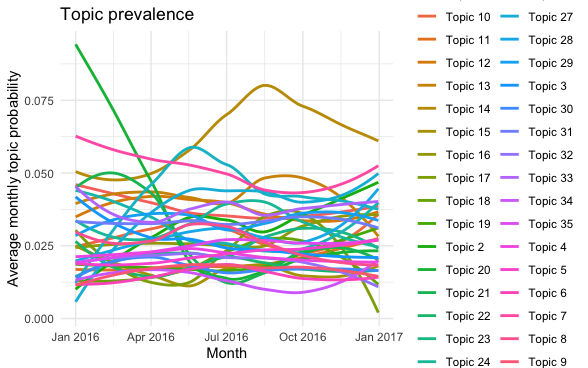

```r
knitr::include_graphics("~/Desktop/QTA_Spring23/Homework2/Rplot.png")
```

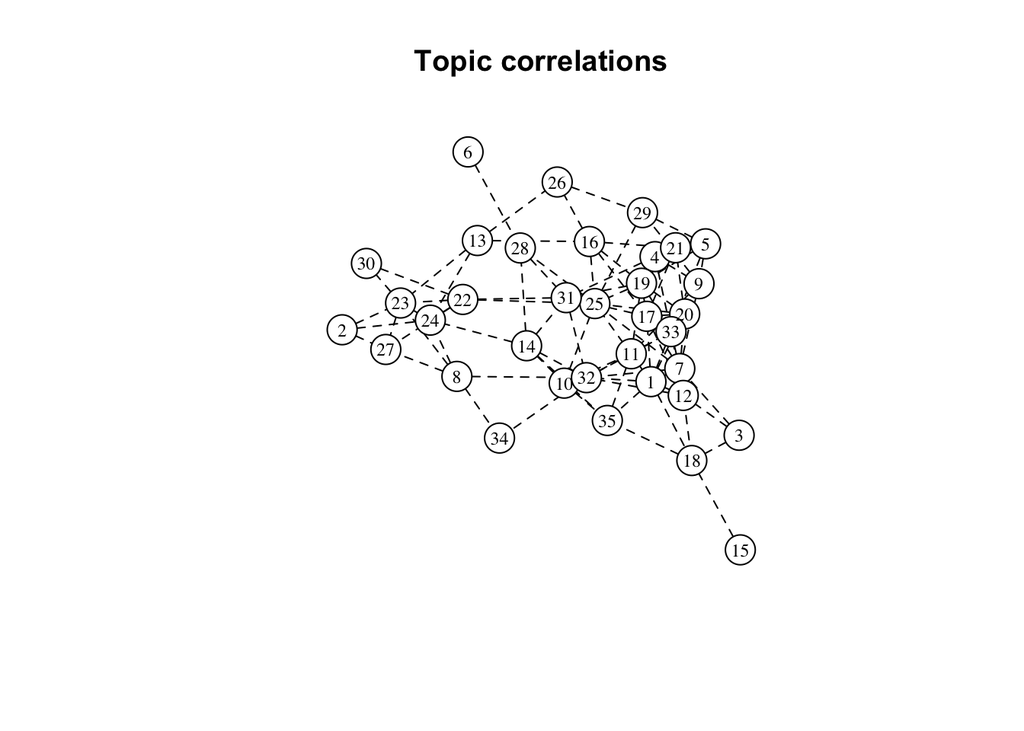

```r
agg_theta <- readRDS('~/Desktop/QTA_Spring23/Homework2/agg_theta')

## 5. Semantic validation (topic correlations)
topic_correlations <- topicCorr(modelFit)
plot.topicCorr(topic_correlations,
               vlabels = seq(1:ncol(modelFit$theta)), # we could change this to a vector of meaningful labels
               vertex.color = "white",
               main = "Topic correlations")
```

```r
## 6. Topic quality (semantic coherence and exclusivity)
topicQuality(model = modelFit,
             documents = stmdfm$documents,
             xlab = "Semantic Coherence",
             ylab = "Exclusivity",
             labels = 1:ncol(modelFit$theta),
             M = 15)
```

```
##  [1] -400.4915 -398.2302 -212.5467 -354.2486 -510.6152 -415.2430 -284.4034
##  [8] -286.7303 -309.4272 -474.2412 -286.1006 -268.5147 -270.6894 -341.0440
## [15] -474.7613 -363.2858 -484.7206 -424.7825 -365.8200 -318.1467 -209.3175
## [22] -347.2042 -245.3125 -505.6939 -394.6218 -317.7767 -562.5239 -415.5484
## [29] -445.0900 -351.4063 -391.2614 -321.2558 -267.4034 -434.3223 -399.9392
##  [1] 14.92537 14.74555 14.65265 14.68419 14.44274 14.86163 14.62849 14.53385
##  [9] 14.45547 14.87752 14.70316 14.37792 14.55373 14.48082 14.71103 14.74361
## [17] 14.68567 14.94176 14.36211 14.68883 14.77627 14.79416 14.84144 14.85655
## [25] 14.82928 14.86663 14.95976 14.64015 14.65185 14.78329 14.74409 14.95181
## [33] 14.87503 14.94823 14.78156
```

[figure not shown]

5. What insights can be gleaned about right-wing media coverage of the 2016 US election? What election-related topics were derived from the model? What interesting temporal patterns exist? Why might the prevalence of certain important topics vary over 2016? Provide evidence in support of your answers.

The graph is cyclical with two main issues peaking the first notable is the discusssion of trump himself which is really strong begining in the early stage of the election year and unusually is down before he official yis the republican nomination but presumably due to the strength of his candidacy. Topic 27 has a broef jump due to a flare up in israel palestine relations.